# 4,222 Introduction to Programming

Lecture 1: Introduction

Dr. Franziska Bender, Dr. Aurélien Sallin

2026-02-20

# Welcome to Introduction to Programming!

## The reality of economics research and work

#### Whether you’re working with data or with economic models, …

- You will write **code** and **documents** on your own machine.
- You will **collaborate** with colleagues, for your thesis, research projects, and in industry.
- You will **share**, **publish** and **reuse** your code.

#### … and …

- **Someone else** will need to run your code, understand it, and build on it.

## This course is about programming

##### Learning to program has become comparatively easy

- Learn a programming language like **R** or **Python**,
- Write code that works on your machine,
- Solve problems with models or data

#### … are now the A-B-C of an economist’s toolkit.

## … and programming with reproducibility

##### Learning to program in a way that is reproducible, reusable and collaborative is harder

- Design and execute projects in a systematic and reproducible way.
- Write code that is reusable, maintainable and easy to share.
- Apply collaborative code development practices.

[figure not shown]

## Skills you’ll develop in this course

- Write **modular code**, **document functions**, implement **error handling**.
- Collaborate using **Git** and **version control**, manage shared code.
- Structure data in **relational databases** and query with **SQL** for systematic data workflows.
- Produce code that works not just on your machine, but in settings that reflect real work in research and industry.

## Let’s get to work!

- Learn essential programming practices in **Python**.
- Build tools using **object oriented programming**.
- Learn **git** and **github**.
- Learn **SQL** and **relational databases**.

#### At the end of this course, you will be able to produce structured and impactful work as an economist.

## This course is introductory, and it is not…

#### Introductory yes ✅, but not in the traditional sense of the term ❌.

- As said, learning a new programming language (Python) has become comparatively easier.
- We will cover the basics of Python, but always with the goal of learning to program in a way that is reproducible, reusable and collaborative.
- All of you know R because of Data Handling, many of you did DSF, you are learning Econometrics this semester: an introduction to programming is beyond the point.
- We want you to develop a **mindset**!

## Warning on the course

- This is the first time we give this course.
- The materials are new, the syllabus is new.
- We will be learning and improving the course together with you.

# About us

## About us

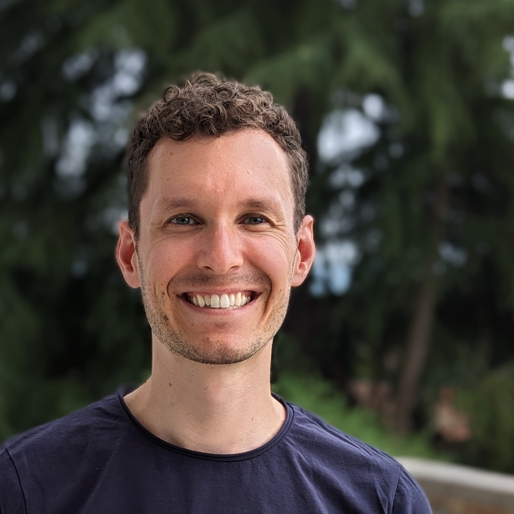

[figure not shown]

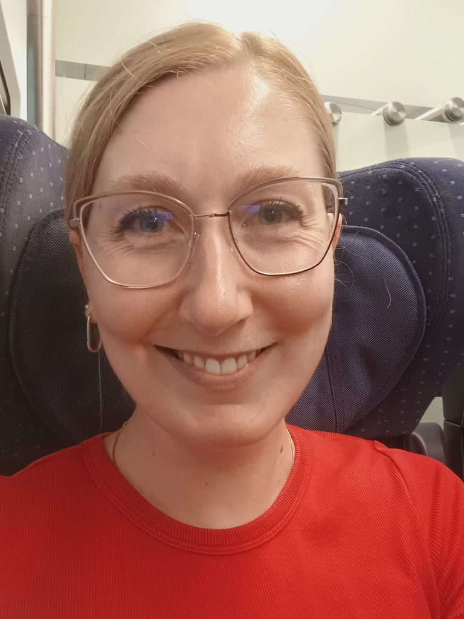

[figure not shown]

Aurélien  
Sallin

Franziska  
Bender

Lea  
Tschan

Valentina  
Sontheim

Andrija  
Lukovic

Johannes  
Cordier

# Course structure and Syllabus

## Course concept: lectures

- 11 Lectures (Friday morning)
  - Background/Concepts
  - Some classes will be focused on programming together, others will be more theoretical.

## Course concept: exercises

- 8 weekly exercise sessions
  - Hands-on exercises/tutorials with exercise sheets handed out every other week
  - Two groups, 4 teaching assistants. One assistant leads the session, the other one assists you personally.
  - **Starts at 12:30** without break until 14:00.
- Q&A sessions for the group project: **08.05.2026** and **15.05.2026**.

## Course structure: part 1

##### Set up your environment, learn to work together with version control and git.

| **Lecture 1** | The big picture. Set up your environment. | Aurélien & Franziska | 20.02.2026 |
| --- | --- | --- | --- |
| **Lecture 2** | Working together: intro to version control and git | Aurélien | 27.02.2026 |
| **Lecture 3** | Working together: more about version control and git | Aurélien | 06.03.2026 |

## Course structure: part 2

##### Learn Python from basics to classes, error handling, documentation, and debugging.

| **Lecture 4** | Intro to python | Franziska | 13.03.2026 |
| --- | --- | --- | --- |
| **Lecture 5** | Python for Data: Pandas and Matplotlib | Franziska | 20.03.2026 |
| **Lecture 6** | Python for Data: Pandas and Matplotlib | Franziska | 27.03.2026 |
| *Break* |  |  |  |
| **Lecture 7** | Python: Introduction to Classes (OOP) | Franziska | 17.04.2026 |
| Publication of group project, deadline for group formation |  |  | 20.04.2026 |
| **Lecture 8** | Error Handling, Documentation, Debugging | Franziska | 24.04.2026 |

- Exercises:
  - Session 4: **13.03.2026**
  - Session 5: **20.03.2026**
  - Session 6: **27.03.2026**
  - Session 7: **17.04.2026**

## Course structure: part 3

##### Learn about databases, SQL, and DevOps practices.

| **Lecture 9** | Short overview of databases and relational database management systems | Aurélien | 01.05.2026 |
| --- | --- | --- | --- |
| **Lecture 10** | Devops, Continuous Integration | Aurélien | 08.05.2026 |
| **Lecture 11** | Conclusion, Q&A, Case Study | Aurélien & Franziska | 15.05.2026 |
| Submission Group Project |  |  | 20.05.2026, 23:59 |
| **Lecture 12** | Exam | Aurélien & Franziska | 22.05.2026 |

- Exercises:
  - Session 8: **01.05.2026**
  - Q&A session 1: **08.05.2026**
  - Q&A session 2: **15.05.2026**
  - No exercise session on 22.05.2026.

# Examination

## Exam information: group project

#### Goals

- Use real-world data in a project to practice and reinforce the concepts covered in the course.

#### Project timeline

- **May 20th, 23:59**: Submission.
- **April 20th**: Project.
- **April 20TH**: Deadline fro group formation. Group of five people.

## Exam

- **May 22nd, 10:15**: Exam.
- Questions about project and course. Multiple choice for lectures, and essay questions to the group project.
- You don’t need to write code, but you need to understand code and interpret it.

# The tools

## Core course resources

- Everything on Canvas, then on github
- Only one Canvas page
- Questions only through Canvas forum!

## Contact for personal questions only!

Aurélien : until Break

Franziska: after break.

Do not contact the assistants.